# Take Home Exercise 3

This week in class we learned about visualising data along with its statistical analysis.

Sean Samuel Prajs https://github.com/SeanP0110 (SMU)  
2022/02/20

# Library Upload

```r
packages = c('ggstatsplot','ggside','tidyverse','stringr','readxl',
             'parallelPlot', 'afex')

for(p in packages){
  if(!require(p, character.only = T)){
    install.packages(p)
  }
}
```

# Exercise 1

## Problem Statement

Create a data visualisation showing average rating and proportion of cocoa percent (% chocolate) greater than or equal to 70% by top 15 company location. For the purpose of this task, chocolate.csv should be used.

## Data Preparation

#### Uploading the data

```r
choc <- read.csv("data/chocolate.csv")

#### Summary of Data
head(choc)
```

```
   ref company_manufacturer company_location review_date
1 2454                 5150           U.S.A.        2019
2 2458                 5150           U.S.A.        2019
3 2454                 5150           U.S.A.        2019
4 2542                 5150           U.S.A.        2021
5 2546                 5150           U.S.A.        2021
6 2546                 5150           U.S.A.        2021
  country_of_bean_origin specific_bean_origin_or_bar_name
1               Tanzania            Kokoa Kamili, batch 1
2     Dominican Republic                  Zorzal, batch 1
3             Madagascar           Bejofo Estate, batch 1
4                   Fiji            Matasawalevu, batch 1
5              Venezuela            Sur del Lago, batch 1
6                 Uganda         Semuliki Forest, batch 1
  cocoa_percent ingredients    most_memorable_characteristics rating
1           76%    3- B,S,C         rich cocoa, fatty, bready   3.25
2           76%    3- B,S,C            cocoa, vegetal, savory   3.50
3           76%    3- B,S,C      cocoa, blackberry, full body   3.75
4           68%    3- B,S,C               chewy, off, rubbery   3.00
5           72%    3- B,S,C fatty, earthy, moss, nutty,chalky   3.00
6           80%    3- B,S,C mildly bitter, basic cocoa, fatty   3.25
```

```r
str(choc)
```

```
'data.frame':   2530 obs. of  10 variables:
 $ ref                             : int  2454 2458 2454 2542 2546 2546 2542 797 797 1011 ...
 $ company_manufacturer            : chr  "5150" "5150" "5150" "5150" ...
 $ company_location                : chr  "U.S.A." "U.S.A." "U.S.A." "U.S.A." ...
 $ review_date                     : int  2019 2019 2019 2021 2021 2021 2021 2012 2012 2013 ...
 $ country_of_bean_origin          : chr  "Tanzania" "Dominican Republic" "Madagascar" "Fiji" ...
 $ specific_bean_origin_or_bar_name: chr  "Kokoa Kamili, batch 1" "Zorzal, batch 1" "Bejofo Estate, batch 1" "Matasawalevu, batch 1" ...
 $ cocoa_percent                   : chr  "76%" "76%" "76%" "68%" ...
 $ ingredients                     : chr  "3- B,S,C" "3- B,S,C" "3- B,S,C" "3- B,S,C" ...
 $ most_memorable_characteristics  : chr  "rich cocoa, fatty, bready" "cocoa, vegetal, savory" "cocoa, blackberry, full body" "chewy, off, rubbery" ...
 $ rating                          : num  3.25 3.5 3.75 3 3 3.25 3.5 3.5 3.75 2.75 ...
```

There are a lot of columns here. Let us take out the unnecessary ones.

```r
choc_nec <- choc[, c(1:3,7,10)]
str(choc_nec)
```

```
'data.frame':   2530 obs. of  5 variables:
 $ ref                 : int  2454 2458 2454 2542 2546 2546 2542 797 797 1011 ...
 $ company_manufacturer: chr  "5150" "5150" "5150" "5150" ...
 $ company_location    : chr  "U.S.A." "U.S.A." "U.S.A." "U.S.A." ...
 $ cocoa_percent       : chr  "76%" "76%" "76%" "68%" ...
 $ rating              : num  3.25 3.5 3.75 3 3 3.25 3.5 3.5 3.75 2.75 ...
```

Notice how the chocolate percentage is a character value? Let us strip the string of the percentage sign and convert it to a decimal number for easier filtering.

```r
choc_nec$cocoa_percent <- (str_remove_all(choc_nec$cocoa_percent,"%") %>% as.numeric())/100
str(choc_nec)
```

```
'data.frame':   2530 obs. of  5 variables:
 $ ref                 : int  2454 2458 2454 2542 2546 2546 2542 797 797 1011 ...
 $ company_manufacturer: chr  "5150" "5150" "5150" "5150" ...
 $ company_location    : chr  "U.S.A." "U.S.A." "U.S.A." "U.S.A." ...
 $ cocoa_percent       : num  0.76 0.76 0.76 0.68 0.72 0.8 0.68 0.7 0.63 0.7 ...
 $ rating              : num  3.25 3.5 3.75 3 3 3.25 3.5 3.5 3.75 2.75 ...
```

Now let us filter out all the chocolate that has less than 70%.

```r
choc_nec <- choc_nec %>% filter(cocoa_percent >=0.7)
str(choc_nec)
```

```
'data.frame':   2144 obs. of  5 variables:
 $ ref                 : int  2454 2458 2454 2546 2546 797 1011 1015 1011 1015 ...
 $ company_manufacturer: chr  "5150" "5150" "5150" "5150" ...
 $ company_location    : chr  "U.S.A." "U.S.A." "U.S.A." "U.S.A." ...
 $ cocoa_percent       : num  0.76 0.76 0.76 0.72 0.8 0.7 0.7 0.7 0.7 0.7 ...
 $ rating              : num  3.25 3.5 3.75 3 3.25 3.5 2.75 2.75 3 3 ...
```

The chocolate needs to be grouped by its location for comparison.

```r
choc_grouped <- choc_nec[,c(3:5)] %>%
  group_by(company_location) %>%
  summarise(
    cocoa_percent = mean(cocoa_percent),
    rating = mean(rating)
  )
```

Lastly, for the prep we need to order the locations by highest rating to lowest.

```r
choc_grouped <- choc_grouped[order(-choc_grouped$rating),]
choc_grouped
```

```
# A tibble: 66 x 3
   company_location cocoa_percent rating
   <chr>                    <dbl>  <dbl>
 1 Chile                    0.7     3.75
 2 Fiji                     0.8     3.42
 3 Denmark                  0.711   3.39
 4 Switzerland              0.733   3.38
 5 Poland                   0.719   3.38
 6 Colombia                 0.708   3.35
 7 Vietnam                  0.745   3.35
 8 Guatemala                0.727   3.34
 9 Australia                0.716   3.34
10 U.A.E.                   0.72    3.33
# ... with 56 more rows
```

## Plot

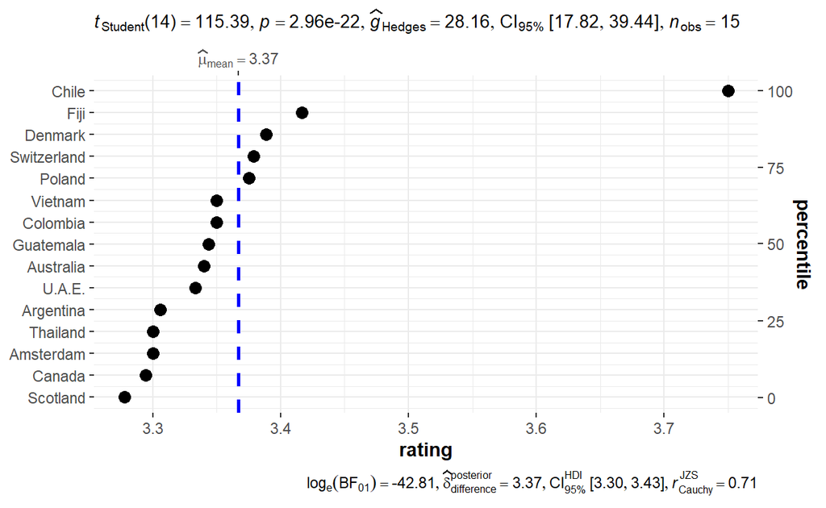

```r
ggdotplotstats(data = choc_grouped[1:15,], y = "company_location", x = "rating")
```

# Exercise 2

## Problem Statement

Create a data visualisation to provide an unbiased comparison of order returned by state. For the purpose of this task, Superstore-2021.xls should be used.

## Data Prep

```r
data <- read_xls("data/Superstore-2021.xls")
colnames(data)
```

```
 [1] "Row ID"         "Order ID"       "Order Date"
 [4] "Ship Date"      "Ship Mode"      "Customer ID"
 [7] "Customer Name"  "Segment"        "Country/Region"
[10] "City"           "State"          "Postal Code"
[13] "Region"         "Product ID"     "Category"
[16] "Sub-Category"   "Product Name"   "Sales"
[19] "Quantity"       "Discount"       "Profit"
```

```r
data_grouped <- dplyr::group_by(data, "State") %>%
  dplyr::summarise(
    Profit = mean(Profit),
    Sales = mean(Sales))
data_grouped
```

```
# A tibble: 1 x 3
  `"State"` Profit Sales
  <chr>      <dbl> <dbl>
1 State       28.7  230.
```

## Plot

```r
ggwithinstats(
  data = data_grouped,
  x = State,
  y = Profit)
```

[output not shown]

# Exercise 3

## Problem Statement

Create a data visualisation to segment kid drinks and other by nutrition indicators. For the purpose of this task, starbucks_drink.csv should be used.

## Data Preparation

```r
drinks <- read.csv("data/starbucks_drink.csv")
str(drinks)
```

```
'data.frame':   2068 obs. of  18 variables:
 $ Category             : chr  "iced-coffee" "iced-coffee" "iced-coffee" "iced-coffee" ...
 $ Name                 : chr  "Cold Brew with Cascara Cold Foam" "Cold Brew with Cascara Cold Foam" "Cold Brew with Cascara Cold Foam" "Cold Brew with Cascara Cold Foam" ...
 $ Portion.fl.oz.       : num  12 16 24 30 30 30 12 12 16 16 ...
 $ Calories             : int  50 80 100 130 160 5 60 0 80 5 ...
 $ Calories.from.fat    : int  0 0 0 0 0 0 0 0 0 0 ...
 $ Total.Fat.g.         : num  0 0 0 0 0 0 0 0 0 0 ...
 $ Saturated.fat.g.     : num  0 0 0 0 0 0 0 0 0 0 ...
 $ Trans.fat.g.         : num  0 0 0 0 0 0 0 0 0 0 ...
 $ Cholesterol.mg.      : int  0 0 0 0 0 0 0 0 0 0 ...
 $ Sodium.mg.           : int  25 30 40 45 15 10 10 0 10 5 ...
 $ Total.Carbohydrate.g.: int  11 17 22 28 40 0 15 0 20 0 ...
 $ Dietary.Fiber.g.     : int  0 0 0 0 0 0 0 0 0 0 ...
 $ Sugars.g.            : int  11 17 22 28 39 0 15 0 20 0 ...
 $ Protein.g.           : int  1 2 2 2 1 1 0 0 0 0 ...
 $ Caffeine.mg.         : chr  "145" "190" "280" "320" ...
 $ Size                 : chr  "Tall" "Grande" "Venti Iced" "Trenta Iced" ...
 $ Milk                 : chr  "" "" "" "" ...
 $ Whipped.Cream        : chr  "" "" "" "" ...
```

```r
unique(drinks$Category)
```

```
 [1] "iced-coffee"                   "refreshers"
 [3] "evolution-fresh"               "iced-tea"
 [5] "bottled-drinks"                "brewed-coffee"
 [7] "espresso"                      "frappuccino-blended-beverages"
 [9] "kids-drinks-and-other"         "tea"
```

```r
kids <- drinks %>% filter(Category=="kids-drinks-and-other")
kids_nutr <- kids[,c(2:15)]
```

## Plot

The code for this visualisation has been referenced from the hands-on exercise of week 5 on parallel plots.

```r
histoVisibility <- rep(TRUE, ncol(kids_nutr))
parallelPlot(kids_nutr,
             rotateTitle = TRUE,
             histoVisibility = histoVisibility)
```

[interactive chart not shown]